# 3-phase VSI

A three-phase voltage source inverter is connected to a balanced three-phase star connected resistive load of $30\,$kW. The inverter is operated with 180 degree conduction mode. If the inverter DC link is connected to a $600\,$V battery, what is the RMS current through the battery?

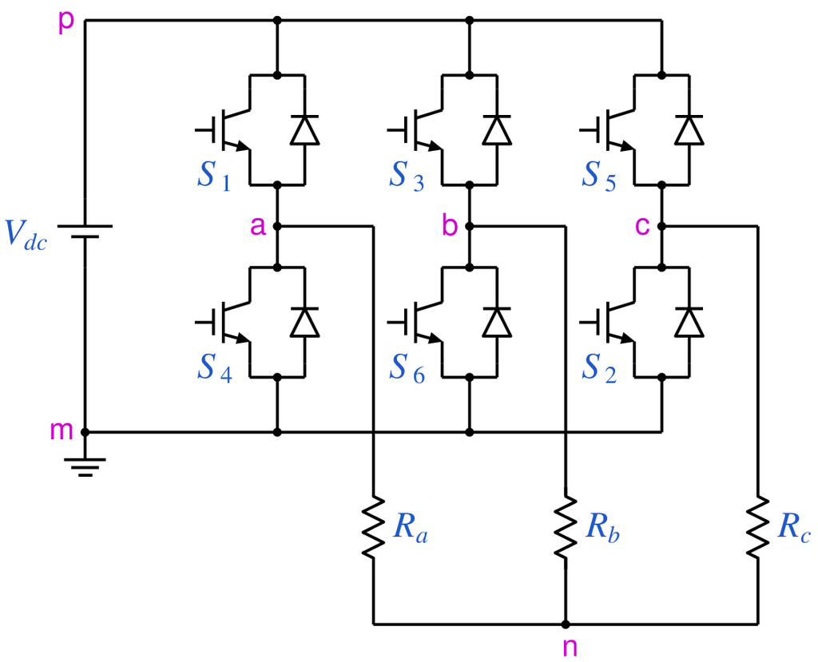

```python
from IPython.display import Image
Image(filename =r'VSI_3ph_9_fig_1.png', width=350)
```

```python
# run this cell to view the circuit file.
%pycat VSI_3ph_9_orig.in
```

We now replace the strings such as \$Vdc, \$L, with the values of our choice by running the python script given below. It takes an existing circuit file `VSI_3ph_9_orig.in` and produces a new circuit file `VSI_3ph_9.in`, after replacing \$Vdcby2, \$L, etc. with values of our choice.

```python
import gseim_calc as calc
s_Vdc = "600"
Vdc = float(s_Vdc)

P = 30.0e3
R = (2/3)*Vdc*Vdc/P
s_f_clock = "50"
s_R = ("%11.4E"%R).strip()

l = [
  ('$Vdc', s_Vdc),
  ('$R', s_R),
  ('$f_clock', s_f_clock),
]
calc.replace_strings_1("VSI_3ph_9_orig.in", "VSI_3ph_9.in", l)
print('VSI_3ph_9.in is ready for execution')
```

```
VSI_3ph_9.in is ready for execution
```

**Execute the following cell to run GSEIM on VSI_3ph_9.in.**

```python
import os
import dos_unix
# uncomment for windows:
#dos_unix.d2u("VSI_3ph_9.in")
os.system('run_gseim VSI_3ph_9.in')
```

```
Circuit: filename = VSI_3ph_9.in
main: calling solve_trns
Transient simulation starts...
i=0
i=1000
i=2000
GSEIM: Program completed.
```

```
0
```

The circuit file (`VSI_3ph_9.in`) is created in the same directory as that used for launching Jupyter notebook. The last step (i.e., running `GSEIM` on `VSI_3ph_9.in`) creates data files called `VSI_3ph_9_1.dat`, etc. in the same directory. We can now use the python code below to compute/plot the various quantities of interest.

```
filename: VSI_3ph_9_3.dat
filename: VSI_3ph_9_1.dat
filename: VSI_3ph_9_2.dat
rms value of IS:  5.0000E+01
```

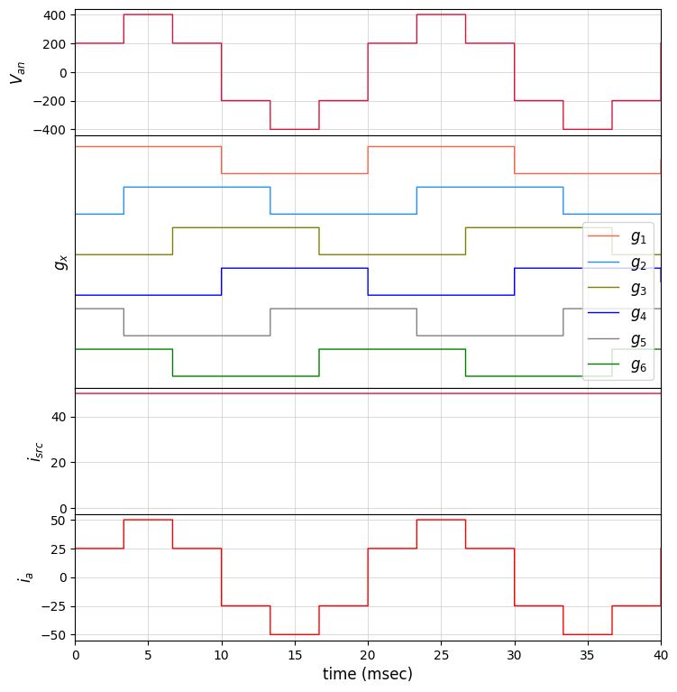

```python
import numpy as np
import matplotlib.pyplot as plt
import gseim_calc as calc
from setsize import set_size

f_hz = 50.0
T = 1.0/f_hz

slv = calc.slv("VSI_3ph_9.in")

i_slv = 0
i_out = 2
filename = slv.l_filename_all[i_slv][i_out]
print('filename:', filename)
u1 = np.loadtxt(filename)
t1 = u1[:, 0]

IRa = slv.get_array_double(i_slv,i_out,"IRa",u1)
IS  = slv.get_array_double(i_slv,i_out,"IS",u1)

i_out = 0
filename = slv.l_filename_all[i_slv][i_out]
print('filename:', filename)
u2 = np.loadtxt(filename)
t2 = u2[:, 0]

g1 = slv.get_array_double(i_slv,i_out,"g1",u2)
g2 = slv.get_array_double(i_slv,i_out,"g2",u2)
g3 = slv.get_array_double(i_slv,i_out,"g3",u2)
g4 = slv.get_array_double(i_slv,i_out,"g4",u2)
g5 = slv.get_array_double(i_slv,i_out,"g5",u2)
g6 = slv.get_array_double(i_slv,i_out,"g6",u2)

i_out = 1
filename = slv.l_filename_all[i_slv][i_out]
print('filename:', filename)
u3 = np.loadtxt(filename)
t3 = u3[:, 0]

v_an = slv.get_array_double(i_slv,i_out,"v_an",u3)

l_IS = calc.avg_rms_3a(t1, IS, 0.0, 2.0*T, 1.0e-5*T)
print('rms value of IS:', "%11.4E"%(l_IS[1]))

fig, ax = plt.subplots(4, sharex=False, gridspec_kw={'height_ratios': [1, 2, 1, 1]})
plt.subplots_adjust(wspace=0, hspace=0.0)

set_size(6.5, 7, ax[0])

for i in range(4):
    ax[i].set_xlim(left=0.0, right=2.0*T*1e3)
    ax[i].grid(color='#CCCCCC', linestyle='solid', linewidth=0.5)

ax[0].set_ylabel(r'$V_{an}$' , fontsize=12)
ax[1].set_ylabel(r'$g_x$'    , fontsize=12)
ax[2].set_ylabel(r'$i_{src}$', fontsize=12)
ax[3].set_ylabel(r'$i_a$'    , fontsize=12)

for i in range(3):
    ax[i].tick_params(labelbottom=False)

color1 = "tomato"
color2 = "dodgerblue"
color3 = "olive"
color4 = "blue"
color5 = "grey"
color6 = "green"
color7 = "crimson"
color8 = "red"

ax[0].plot(t3*1e3, v_an, color=color7, linewidth=1.0, label="$V_{an}$")

dy = 1.5

ax[1].plot(t2*1e3, (g1       ), color=color1, linewidth=1.0, label="$g_1$")
ax[1].plot(t2*1e3, (g2 -   dy), color=color2, linewidth=1.0, label="$g_2$")
ax[1].plot(t2*1e3, (g3 - 2*dy), color=color3, linewidth=1.0, label="$g_3$")
ax[1].plot(t2*1e3, (g4 - 3*dy), color=color4, linewidth=1.0, label="$g_4$")
ax[1].plot(t2*1e3, (g5 - 4*dy), color=color5, linewidth=1.0, label="$g_5$")
ax[1].plot(t2*1e3, (g6 - 5*dy), color=color6, linewidth=1.0, label="$g_6$")

ax[1].tick_params(left = False)
ax[1].set_yticks([])

ax[2].plot(t1*1e3, IS , color=color7, linewidth=1.0, label="$i_{src}$")
ax[3].plot(t1*1e3, IRa, color=color8, linewidth=1.0, label="$i_a$")

ax[3].set_xlabel('time (msec)', fontsize=12)

ax[1].legend(loc = 'lower right',frameon = True, fontsize = 10, title = None,
    markerfirst = True, markerscale = 1.0, labelspacing = 0.5, columnspacing = 2.0,
    prop = {'size' : 12})

#plt.tight_layout()
plt.show()
```

This notebook was contributed by **Prof. Nakul Narayanan K**, Govt. Engineering College, Thrissur. He may be contacted at nakul@gectcr.ac.in.